# Coursework Report

*N* removed NAs: 2

*N* removed typo: 1

*N* removed <18: 16

*N* total clean: 132

| Group | *N* | *M*<sub>age</sub> | *M*<sub>rating</sub> |
| --- | --- | --- | --- |
| Control | 72 | 21.2 | 6.82 |
| Experim | 60 | 21.2 | 5.59 |

**Main analysis results**

*t*(130) = 9.87, *p* < .001

[interactive chart not shown]

[figure not shown]

[interactive chart not shown]

# Coursework Report

Analysing Data, Spring 2020

This student has a record of specific learning difficulty (dyslexia/dyspraxia). Please mark this report in accordance with the [marking guidelines for SLD](https://www.sussex.ac.uk/studentsupport/staff/spld?fbclid=IwAR2lYKD6xvuv9egQDvG8d_oed9GUD3KXQn3gAdlHZ1gQB8gDddBdeOEmKdE).

# Methods

## Participants

| Group | Mean age | Number of participants |
| --- | --- | --- |
| Experimental | 21.23 | 60 |
| Control | 21.21 | 72 |

**Figure 1: Table of participant descriptives by experimental condition.**

## Design

The conceptual hypothesis is “Does colour influence attractiveness”. The independent variable was the condition in which the partipants were randomly assigned to, as it is a between groups design. There were two conditions, the control condition in which participants viewed the photograph on a white background, or the experimental condition in which the participants viewed the photograph on a red background.The group they were assigned to was recorded in r as a factor. The participants were asked 3 questions related to the mans attractiveness in which they submitted a rating on a 9 point scale ranging from 1 being not attractive at all to 9 being extremely attractive.The questions were “How attractive do you think this person is”, “How pleasant is this person to look at” and “If i were to meet the person in this picture face to face, I would think he is attractive”. These questions were recorded numerically as a double. The level of attractiveness measured on this scale was the dependent variable. The operationalised hypothesis is “Do the mean attractiveness ratings change when viewing the same man within different colour frames”. In order to see whether my hypothesis is correct i will use a statistical analysis. I will use an independent t test to determine whether the population means for each condition are signficantly different.The null hypotheses was that “Colour has no effect on attractivness ratings”.

# Results

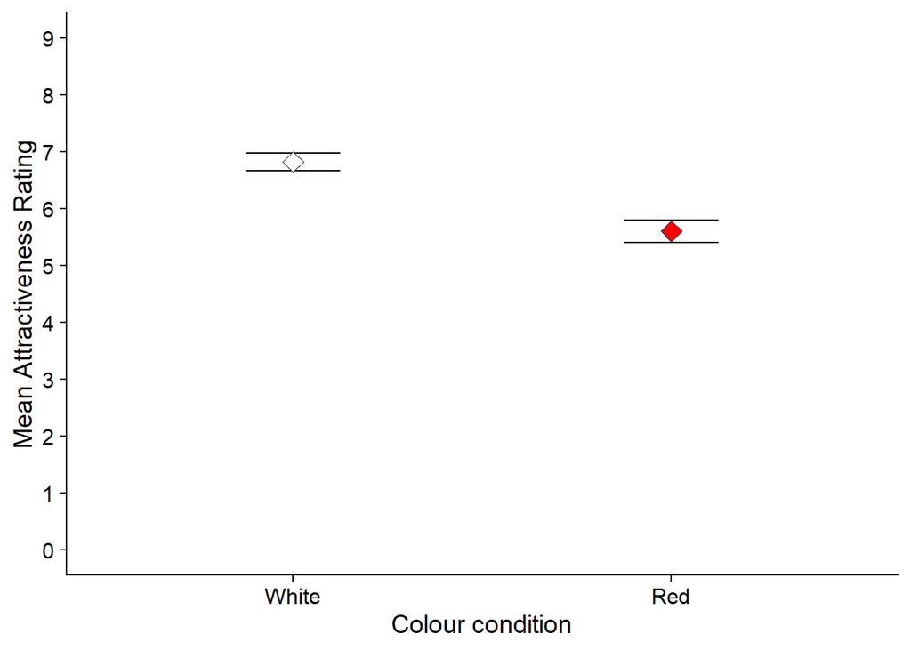

**Figure 2: Mean attractiveness rating in the different colour conditions.**

# Discussion

The results of my study have contradicted the original study carried out by Elliot in 2010. Both studies found a significant difference in mean ratings of attractiveness due to the colour of frame, however my study found that the colour condition “White” actually had the highest mean attractiveness rating. The findings in my study weaken the reliability of Elliots original study as it shows that it has poor test re-test reliability, given that i used the exact same method. The changes in results could be due to a number of factors, firstly it could be due to the participants used, my participants ranged from 18, 30 years old whears Elliots participants ranged from 18-25. Secondly the participants in my experiment could have guessed the purpose of the study and therefore changed their answers to align with what they think i want to see. If i was repeating the study I would ask the participants what they thought the purpose of the study was at the end, just like Elliot (2010) did. This would determine if any demand characteristics were present that could have acted as a confounding variable. The contradictory results suggest that an attractiveness rating based on colour is subjective and may differ from study to study making predictions or generalised statements difficult. The results of previous studies have produced results similar to my study, suggesting my results are not a fluke. In a study that used a comparable method to mine the results are as followed. “Higher attractiveness ratings were not found for the woman in red. Instead, a marginally significant white effect on attractiveness emerged” (Peperkoorn, Roberts, Pollet, 2016). Results such as these increase the reliability of my results.

A limitation of this study and the original one conducted by Elliot (2010) was that it was only studying womens ratings of mens attractiveness in conjunction with the colour red; therefore reducing the external validity. For further research it would be useful to look at the opposite effect of mens ratings of womens attractiveness in conjunction with the colour red. For future studies I would also suggest altering the method to see if similar results are found when a coloured item of clothing is used instead of a coloured frame. Previous research has suggested that a woman wearing red does not increase a mans opinion of them and actually reduces pro social behaviour in the form of tipping (Lynn, Giebelhausen, Garcia and Pautumanon, 2016). This supports my research in that viewing someone in conjunction with the colour red does not increase your opinion of them either in the form of attractiveness or pro social behaviour. However other research has contradicted this suggesting that a woman wearing red increases pro social behaviour, in the form of being offered more lifts whilst hitchiking (Gueguen, 2012).

These studies support my view that reactions to colour is subjective and perhaps not easy to make predicitons about. Whilst i found a significant difference in attractiveness ratings due to frame colour, it wasnt the expected result and contradicted the original study (Elliot, 2010), with white actually producing higher attractiveness ratings. The conflicting evidence suggests that attractiveness ratings or pro social behaviour do not necessarily increase in conjunction with the colour red.

# References

Peperkoorn, L.S., Roberts, S.C., Pollet, T.V., 2016. Revisiting the Red Effect on Attractiveness and Sexual Receptivity: No Effect of the Color Red on Human Mate Preferences. Evol Psychol 14, 1474704916673841. https://doi.org/10.1177/1474704916673841.

Red, rank, and romance in women viewing men - ProQuest [WWW Document], n.d. URL https://search.proquest.com/docview/745195146?accountid=14182 (accessed 3.7.20).